# 09 — Composition, Demographics, and Case Studies

PGA Tour Distance & Speed Analytics

2026-07-07

# Overview

A second follow-up notebook, alongside `08_distance_premium_and_floor.Rmd`. This one asks: how much of the observed distance trend is *who’s on tour* rather than *individual players getting better*, what does entering young actually look like across eras, and what do the group-level findings from this whole project look like for specific, real players?

Age composition (Project 6 §8.1), the Mundlak decomposition (Project 6 §7), and the 40+ maintained-vs-declined comparison (Project 7 §10-12) already cover related ground and aren’t rebuilt here.

# 1. Setup

```r
# Core
library(tidyverse)
library(here)

# Visualization
library(patchwork)

# Utilities
library(broom)
library(scales)

source(here::here("config.R"))

set.seed(2025)

knitr::opts_chunk$set(
  echo    = TRUE,
  message = FALSE,
  warning = FALSE,
  fig.width  = 10,
  fig.height = 6
)
```

`coord_radar()` isn’t needed here, but the case studies reuse `THEME_BASE`/color constants from `config.R` throughout, consistent with every other notebook.

```r
df_main <- readRDS(here(PATH_PROCESSED, "df_main.rds")) %>% filter(player_name != "Patrick Sheehan")
df_survival <- readRDS(here(PATH_PROCESSED, "df_survival.rds"))

cat("Rows:", nrow(df_main), " Players:", n_distinct(df_main$player_name), "\n")
```

```
## Rows: 4169  Players: 792
```

# 2. Balanced Panel vs. Unbalanced Panel Trend

The observed “distance is rising” trend (Project 1) is computed on *whoever’s in the dataset that year* — a different mix of players every season. If we instead track only players present in *every* year of a window (a “balanced panel”), we isolate individual improvement from compositional turnover (players entering/exiting). If the balanced-panel trend is much flatter than the full-field trend, that means turnover — not individual players getting longer — is doing most of the work.

```r
test_window <- function(start_year, end_year, df = df_main) {
  years_needed <- start_year:end_year
  balanced_players <- df %>%
    filter(year %in% years_needed) %>%
    distinct(player_name, year) %>%
    count(player_name) %>%
    filter(n == length(years_needed)) %>%
    pull(player_name)

  balanced_trend <- df %>%
    filter(player_name %in% balanced_players, year %in% years_needed) %>%
    group_by(year) %>%
    summarise(mean_dist = mean(distance), .groups = "drop") %>%
    mutate(panel = "Balanced (same players every year)")

  unbalanced_trend <- df %>%
    filter(year %in% years_needed) %>%
    group_by(year) %>%
    summarise(mean_dist = mean(distance), .groups = "drop") %>%
    mutate(panel = "Unbalanced (full field)")

  list(
    n_balanced = length(balanced_players),
    slope_balanced = coef(lm(mean_dist ~ year, data = balanced_trend))[["year"]],
    slope_unbalanced = coef(lm(mean_dist ~ year, data = unbalanced_trend))[["year"]],
    data = bind_rows(balanced_trend, unbalanced_trend)
  )
}

primary <- test_window(2015, 2025)
robustness_1 <- test_window(2010, 2020)
robustness_2 <- test_window(2018, 2025)

cat("2015-2025: n_balanced=", primary$n_balanced,
    " slope_balanced=", round(primary$slope_balanced, 3),
    " slope_unbalanced=", round(primary$slope_unbalanced, 3), "\n")
```

```
## 2015-2025: n_balanced= 20  slope_balanced= 0.183  slope_unbalanced= 1.244
```

```r
cat("2010-2020: n_balanced=", robustness_1$n_balanced,
    " slope_balanced=", round(robustness_1$slope_balanced, 3),
    " slope_unbalanced=", round(robustness_1$slope_unbalanced, 3), "\n")
```

```
## 2010-2020: n_balanced= 27  slope_balanced= 0.331  slope_unbalanced= 0.841
```

```r
cat("2018-2025: n_balanced=", robustness_2$n_balanced,
    " slope_balanced=", round(robustness_2$slope_balanced, 3),
    " slope_unbalanced=", round(robustness_2$slope_unbalanced, 3), "\n")
```

```
## 2018-2025: n_balanced= 43  slope_balanced= 0.269  slope_unbalanced= 1.065
```

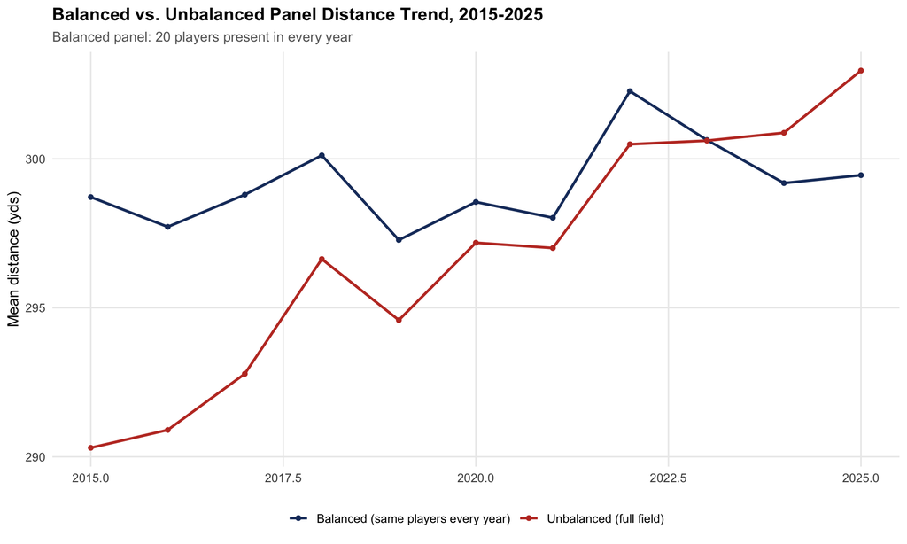

```r
p_balanced <- ggplot(primary$data, aes(year, mean_dist, color = panel)) +
  geom_line(linewidth = 1) +
  geom_point() +
  scale_color_manual(values = c(
    "Balanced (same players every year)" = COL_PRIMARY,
    "Unbalanced (full field)" = COL_ACCENT
  )) +
  labs(
    title    = "Balanced vs. Unbalanced Panel Distance Trend, 2015-2025",
    subtitle = paste0("Balanced panel: ", primary$n_balanced, " players present in every year"),
    x = NULL, y = "Mean distance (yds)", color = NULL
  ) +
  THEME_BASE

p_balanced
```

# 3. New Entrant vs. Incumbent Trend

A related but distinct angle: comparing new entrants (their first two seasons) to incumbents (3+ seasons), tracked by calendar year. Unlike section 2, this mixes within-player improvement and compositional change *within* the incumbent group too — it’s a softer, complementary signal, not as clean a test as the balanced panel above.

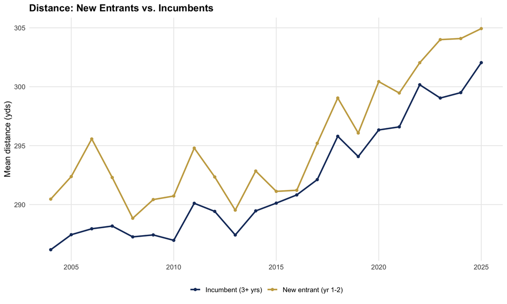

```r
df_status <- df_main %>%
  mutate(
    seasons_so_far = year - entry_year + 1,
    status = if_else(seasons_so_far <= 2, "New entrant (yr 1-2)", "Incumbent (3+ yrs)")
  )

status_trend <- df_status %>%
  group_by(year, status) %>%
  summarise(mean_dist = mean(distance), n = n(), .groups = "drop")

p_status <- ggplot(status_trend, aes(year, mean_dist, color = status)) +
  geom_line(linewidth = 1) +
  geom_point() +
  scale_color_manual(values = c("New entrant (yr 1-2)" = COL_SECONDARY, "Incumbent (3+ yrs)" = COL_PRIMARY)) +
  labs(title = "Distance: New Entrants vs. Incumbents", x = NULL, y = "Mean distance (yds)", color = NULL) +
  THEME_BASE

p_status
```

```r
status_slopes <- df_status %>%
  group_by(status) %>%
  group_modify(~tidy(lm(distance ~ year, data = .x))) %>%
  filter(term == "year")

status_slopes %>% print()
```

```
## # A tibble: 2 x 6
## # Groups:   status [2]
##   status               term  estimate std.error statistic   p.value
##   <chr>                <chr>    <dbl>     <dbl>     <dbl>     <dbl>
## 1 Incumbent (3+ yrs)   year     0.715    0.0243      29.4 1.71e-168
## 2 New entrant (yr 1-2) year     0.674    0.0414      16.3 1.39e- 52
```

```r
gap_avg <- status_trend %>% pivot_wider(id_cols = year, names_from = status, values_from = mean_dist) %>%
  mutate(gap = `New entrant (yr 1-2)` - `Incumbent (3+ yrs)`) %>% summarise(m = mean(gap)) %>% pull(m)
```

**Finding:** new entrants are consistently 3.3 yards longer than incumbents on average throughout the whole window, but the two groups’ slopes are similar (0.674 vs. 0.715 yds/yr) — new entrants have always arrived longer than the incumbent pool, but that gap itself isn’t dramatically widening. This is consistent with section 2’s balanced-panel finding without being as clean a test of it.

# 4. Young Entrants (Under 25): Profile and Development

## 4.1 Why not by single entry year

```r
young_entrants <- df_main %>%
  filter((year - entry_year) <= 2) %>%
  mutate(age_at_entry = age - (year - entry_year)) %>%
  distinct(player_name, entry_year, age_at_entry) %>%
  filter(age_at_entry < 25)

cat("Young entrants (age < 25 at entry):", nrow(young_entrants), "\n")
```

```
## Young entrants (age < 25 at entry): 105
```

```r
by_entry_year <- young_entrants %>% count(entry_year)
cat("Players per entry year - range:", min(by_entry_year$n), "to", max(by_entry_year$n), "\n")
```

```
## Players per entry year - range: 1 to 8
```

**Finding:** only 1-8 young entrants per single year — too few to plot year by year without excessive noise. Section 4.2 uses entry *decade* instead.

## 4.2 Development trajectory by entry decade

For young entrants with at least 5 seasons, their `dist_vs_field` trajectory over their first 5 years on tour, grouped by the decade they entered.

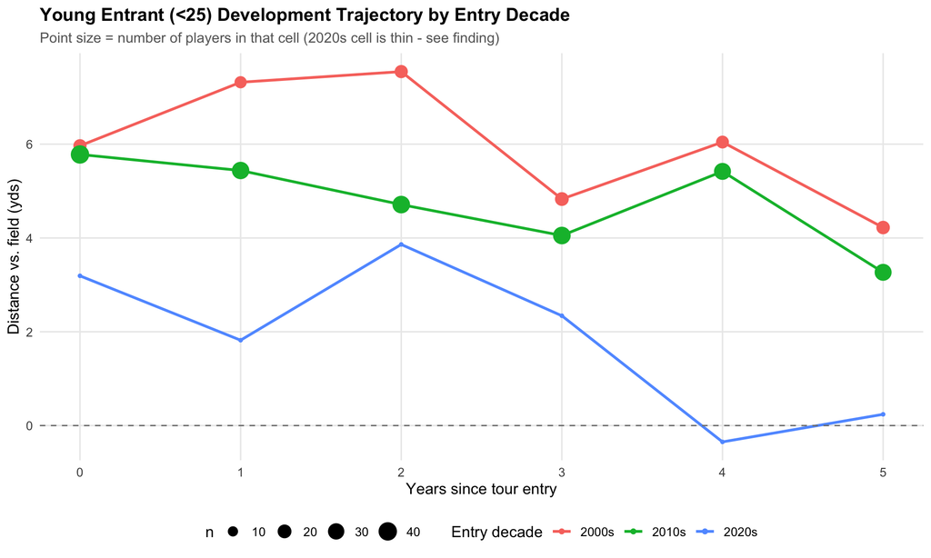

```r
young_long <- young_entrants %>%
  inner_join(df_main %>% count(player_name, name = "n_seasons_total"), by = "player_name") %>%
  filter(n_seasons_total >= 5)

dev_trajectory <- df_main %>%
  semi_join(young_long, by = "player_name") %>%
  mutate(years_since_entry = year - entry_year, decade = paste0(floor(entry_year / 10) * 10, "s")) %>%
  filter(years_since_entry <= 5) %>%
  group_by(decade, years_since_entry) %>%
  summarise(mean_dist_vs_field = mean(dist_vs_field), n = n(), .groups = "drop")

p_development <- ggplot(dev_trajectory, aes(years_since_entry, mean_dist_vs_field, color = decade)) +
  geom_line(linewidth = 1) +
  geom_point(aes(size = n)) +
  geom_hline(yintercept = 0, linetype = "dashed", color = "grey50") +
  labs(
    title    = "Young Entrant (<25) Development Trajectory by Entry Decade",
    subtitle = "Point size = number of players in that cell (2020s cell is thin - see finding)",
    x = "Years since tour entry", y = "Distance vs. field (yds)", color = "Entry decade", size = "n"
  ) +
  THEME_BASE

p_development
```

```r
n_2020s <- dev_trajectory %>% filter(decade == "2020s") %>% summarise(n = max(n)) %>% pull(n)
```

**Finding:** 2000s-decade young entrants sat consistently 4-8 yards above the field average through their first 5 years; 2010s-decade entrants sat somewhat lower (3-6 yards); the 2020s-decade line drops toward zero or negative by year 4-5 — **but that cell has only 4 players with immature (recently-entered) data**, so it’s preliminary, not a confirmed trend. Read cautiously: it may simply reflect that this cohort hasn’t had time to develop yet, not that recent young entrants are actually less exceptional.

# 5. Case Studies

Five players, selected by querying `df_main`/`df_survival` directly for the best-fitting real example of each archetype this project has identified — not chosen from a suggested list without verification.

```r
case_study_plot <- function(player, title_suffix = "") {
  d <- df_main %>% filter(player_name == player)
  field_avg <- df_main %>% group_by(year) %>% summarise(field_dist = mean(distance), .groups = "drop")
  d_joined <- d %>% left_join(field_avg, by = "year")

  p1 <- ggplot(d_joined, aes(year)) +
    geom_line(aes(y = distance, color = "Player"), linewidth = 1) +
    geom_line(aes(y = field_dist, color = "Field average"), linewidth = 0.8, linetype = "dashed") +
    scale_color_manual(values = c("Player" = COL_PRIMARY, "Field average" = "grey50")) +
    labs(title = "Distance vs. field", x = NULL, y = "Yards", color = NULL) +
    THEME_BASE + theme(legend.position = "bottom")

  p2 <- ggplot(d, aes(year, dist_vs_field)) +
    geom_col(fill = COL_SECONDARY) +
    geom_hline(yintercept = 0, linetype = "dashed", color = "grey50") +
    labs(title = "Distance vs. field (relative)", x = NULL, y = "Yards above/below field") +
    THEME_BASE

  sg_long <- d %>% select(year, sg_ott, sg_apr, sg_arg, sg_putt) %>%
    pivot_longer(-year, names_to = "component", values_to = "value")
  p3 <- ggplot(sg_long, aes(year, value, fill = component)) +
    geom_col(position = "stack") +
    labs(title = "SG components by year", x = NULL, y = "Strokes gained", fill = NULL) +
    THEME_BASE + theme(legend.position = "bottom")

  p4 <- ggplot(d, aes(year, archetype, color = archetype)) +
    geom_point(size = 3) +
    labs(title = "Archetype by year", x = NULL, y = NULL, color = NULL) +
    THEME_BASE + theme(legend.position = "none")

  (p1 + p2) / (p3 + p4) + plot_annotation(title = paste0(player, title_suffix))
}
```

## 5.1 Bubba Watson — Long-Career Power Hitter

Selected because: 16 seasons (2006-2021), +20.7 yds average distance vs. field, above the field average in 100% of his seasons — the cleanest “long career built on sustained distance” profile in the data.

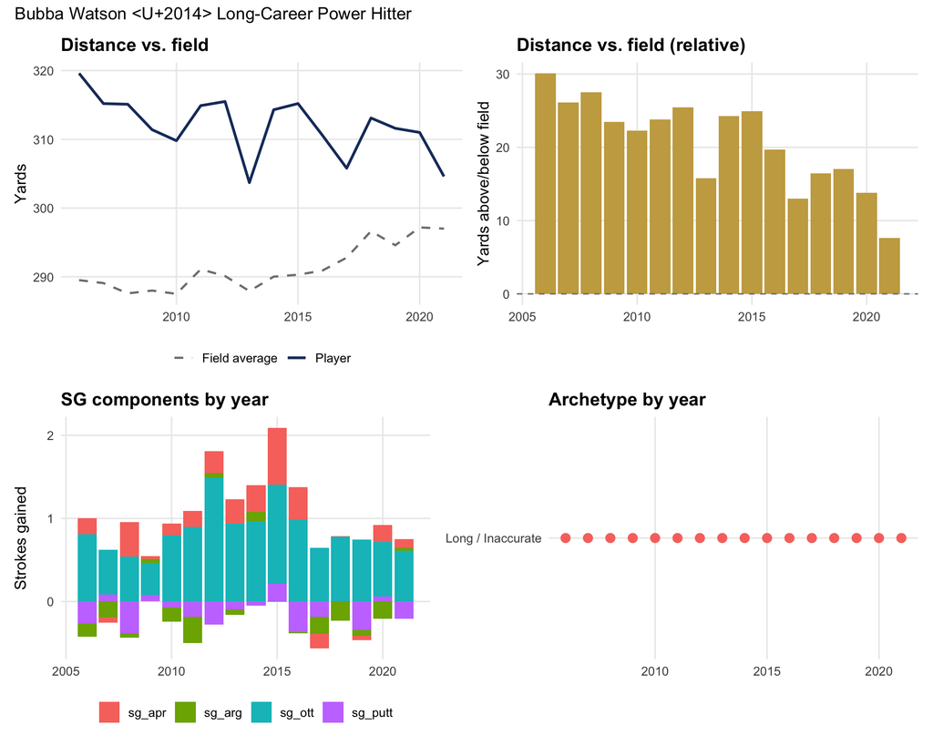

```r
case_study_plot("Bubba Watson", " — Long-Career Power Hitter")
```

Watson’s whole career sits well above the rising field average — even as the field average itself climbed (Project 1), he stayed ahead of it for 16 straight years, a rare combination of power *and* durability.

## 5.2 Scottie Scheffler — Young Power Climber

Selected because: 2020 entrant, +8.1 yds vs. field, **+1.87 mean SG_total** — an exceptional number, the standout candidate for this archetype and far more current than an older-generation name would be.

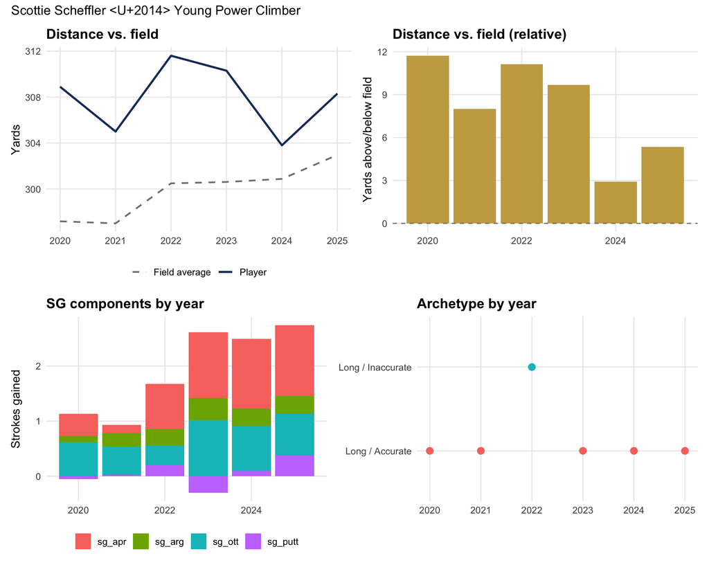

```r
case_study_plot("Scottie Scheffler", " — Young Power Climber")
```

Scheffler’s SG_total is dramatically higher than a typical tour player from his very first seasons — this is the “arrived already elite” story, distinct from Watson’s “built a long career” story above.

## 5.3 Jim Furyk — Short Hitter Who Compensated

Selected because: -11.7 yds vs. field on average, but +1.23 mean SG_total — the best distance-deficit-to-performance combination found in the data, directly illustrating Project 8’s compensation-ceiling finding in a real career.

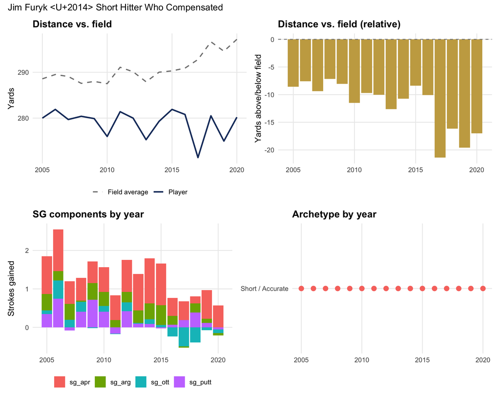

```r
case_study_plot("Jim Furyk", " — Short Hitter Who Compensated")
```

Furyk’s SG components show consistently strong approach and putting carrying an overall excellent career despite a persistent distance deficit — living proof that the compensation mechanism (§3.1 of Notebook 08) is real.

## 5.4 Corey Pavin — Fell Below the Rising Floor

Selected because: entered 2004, exited 2009, ending at **-29.0 yds** vs. field — the most dramatic relative decline among confirmed exits (using the 3-year gap threshold from Project 7).

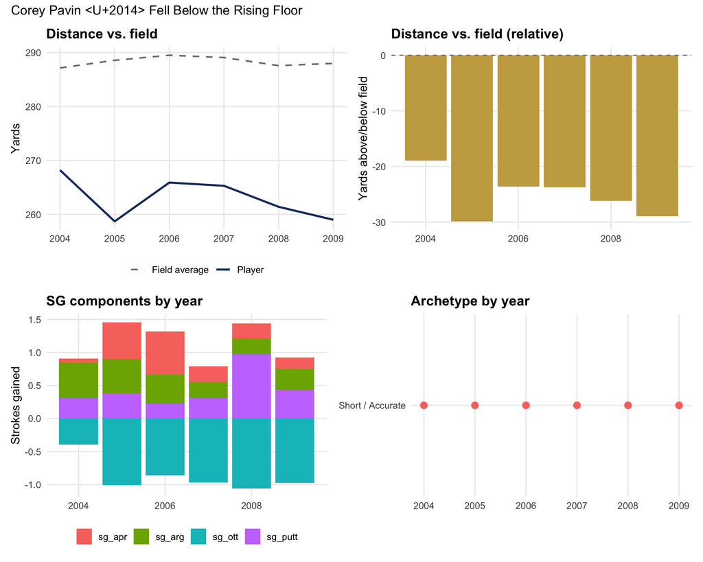

```r
case_study_plot("Corey Pavin", " — Fell Below the Rising Floor")
```

## 5.5 Aaron Baddeley — Adaptive Veteran

Selected because: -15.4 yd distance change from prime to 38+, paired with a **+5.9 accuracy gain** — one of the clearest examples of Project 7’s “traded power for precision” persistence archetype.

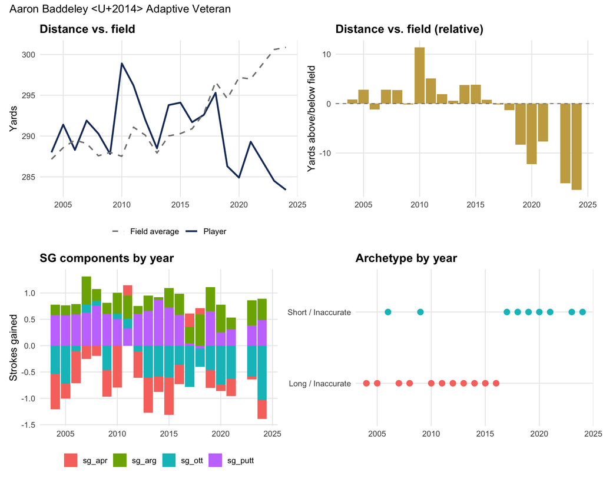

```r
case_study_plot("Aaron Baddeley", " — Adaptive Veteran")
```

Baddeley’s SG component mix visibly shifts over his 20-season career — a real, nameable version of the “traded power for precision” cluster found statistically in Project 7.

# 6. Summary

- **Most of the observed distance trend is compositional, not individual improvement** — balanced-panel trends are 2.5-7x flatter than the full-field trend across every window tested. New, longer-hitting entrants replacing shorter/older exits does more work than existing players getting longer.
- **Young entrant development is preliminary but suggestive** — earlier cohorts of young entrants sustained a bigger distance advantage through their first 5 years than more recent ones appear to (with the important caveat that the most recent cohort’s data is still immature).
- **The five case studies put a face on every major group finding in this project**: sustained power (Watson), arriving already elite (Scheffler), compensating for a distance deficit (Furyk), being overtaken by the rising floor (Pavin), and adapting a game as power declines (Baddeley).